# Edge/Centre Research Program

#### - Education - Human Services - Arts - Imagination - Research - Practice -

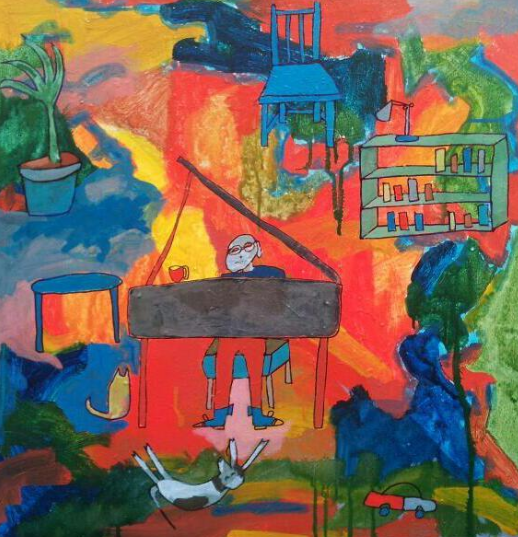

### Introducing the Edge/Centre Research Program

The Edge/Centre includes over 25-years of research and social action collaborations that have transformed into the productive research program that we now call the Edge/Centre. Aspects of the history of this work are documented and includes hosting conferences, community development activities, facilitation of workshops, lobbying, delivery of art-based sessions, participation on steering committees, activism, conference presentations, providing professional development, writing submissions, research projects, and writing, e.g., Crowhurst and Emslie, 2020, 2018, 2014, 2003, 2000a, 2000b.

The Edge/Centre is a space of collaborative scholarly endeavours and creatively designed intellectual pursuits. The Edge/Centre maintains a key focus on investigating and deploying creative research methods and innovative knowledge practices to generate and enhance the possibilities for imaginative ethical professional practice in human services, education and the arts.

### What do we mean by the Edge/Centre?

In Crowhurst and Emslie (2018, p. ix) we describe the Edge/Centre as;

> ‘…an idea and a location where the values of collaboration, emergence, dialogue and creativity drive the generation of…[the] text.’

The Edge/Centre is an idea and a space we inhabit intellectually, emotionally, affectively and physically to think, research, read, play, dialogue, reflect, diffract, squiggle, collaborate, compost, analyse, and write.

The Edge/Centre involves intentionally locating intellectual, emotional and physical labour on the margins. For example, we situate our research and writing as being on the edge of what is typical, prevailing, mainstream, aligned, assumed and expected. Our work is deliberately done on the margins, not in the centre of things, and does not seek to follow mainstream agendas because we find many aspects of these problematic.

> ’We think we write from an edge, an edge that is quirky and different and where our marginality allows for, generates and affords other interesting kinds of connection…[One thing our work] is about storying edges and the generative possibilities that marginality can offer (Crowhurst and Emslie, 2020, p. 6).

The Edge/Centre is an alternative space, a place of difference, that is ‘out there’, edgy, that involves doing edginess, pushing boundaries, and doing things in unexpected and not what is expected or assumed ways. The Edge/Centre also functions as a form of support where edgy work is validated and celebrated.

The Edge/Centre is a ‘pleasurable non-normative space’ that we claim, occupy, inhabit, are captured by, are drawn to and purposefully build as an alternative to the existing middle or neoliberal centre (Crowhurst and Emslie, 2020, p. 23). An example of the effects generated on account of inhabiting the Edge/Centre is the form that our writng takes.

> ‘This edginess is reflected in the texts’ style and in its eclecticism, in its tone, and in its voice and register’ (Crowhurst and Emslie, 2020, p. 6).

### Storying the Edge/Centre’s recent research projects and future initiatives

[**‘Working Creatively with Stories and Learning Experiences: Engaging with Queerly Identifying Tertiary Students’**](https://link.springer.com/book/10.1007/978-3-319-69754-3)

[figure not shown]

Our first book (Crowhurst and Emslie, 2018) outlines a series of methods to work creatively with stories, to open up possibilities in understanding and thinking about stories, and to open up possibilities in stories for generating understanding and meaning in our lives. ‘Working Creatively with Stories and Learning Experiences: Engaging with Queerly Identifying Tertiary Students’ explores how we can work creatively with stories and we used the stories of queerly identifying tertiary students to demonstrate this. In the book we describe and deploy a range of methods to analyse the stories of the students. We make the case that the stories, and the subjectivities they capture are:  
* (ch 2) discursively produced (or an effect of discourse in context)  
* (ch 3) performative (or performed, enacted and embodied)  
* (ch 4) multiple (or consisting of an assemblage of elements)  
Then (ch 5) we argue that the elements of these discursively produced, performative and multiple/fragmented stories/subjectivities can at times be contrary and sit in tension. We argue there is a tendency to ignore, overlook, deny, minimise, and erase such tensions. However, we make the case that such tension, ambiguity, diversity, and complexity in stories/subjectivities has productive potential and is generative of other possibilities. In (ch 6) we make the case that ‘reading aloud like a playscript’ is a way to engage with these possibilities. We argue that these methods can be used to analyse the generative potential of any story whether they be about people, practice, policy, institutions, or contexts.

> *Praise for ‘Working Creatively with Stories and Learning Experiences: Engaging with Queerly Identifying Tertiary Students’:*

*‘At a time when gender and sexual diversity are high on the agenda, this book marks a timely intervention in the tertiary education context. It will be of interest and value to a wide range of professionals working to support LGBTQ students in colleges and universities.’*  
*- Prof Peter Aggleton, University of New South Wales, Australia*

*‘This is a very useful guide not only in support of LGBTIQ issues but also a very accessible academic overview of using, analyzing and creatively engaging with narratives in many disciplines, with many communities, and in multiple settings.’*  
*- Dr Maria Pallotta Chiarolli, Deakin University, Australia*

[**‘Arts-based Pathways into Thinking: Troubling Standardization/s, Enticing Multiplicities, Inhabiting Creative Imaginings’**](https://www.springer.com/gp/book/9783030375065)

[figure not shown]

Our second book (Crowhurst and Emslie, 2020) turns to our stories and we deploy a critical/collective/auto/ethnographic approach to engage with these accounts. Then using the methods from our first book and introducing a series of arts-based research methods we work with our stories to generate possibilities for understanding and thinking about stories in different ways. ‘Arts-based Pathways into Thinking: Troubling Standardization/s, Enticing Multiplicities, Inhabiting Creative Imaginings’ extends the ideas from our first book. In this book (ch 1) we argue that the beginning of the 21st century has seen a marked interest in creative research methods and novel knowledge practices. At the same time, we make the case (ch 2) that we are living in increasingly standardized times that feature systems that specify objectives ahead of time, demand compliance, and narrow the possibilities for human action. It is this contradictory set of conditions that incited and generated this book. In the book we describe and deploy an assemblage of theoretically informed, creative, art-based, and creative/critical/collective/auto/ethnographic methods that aim to trouble and resist standardizations and normativities and provoke multiplicities and the inhabitation of creative imaginings. We provide accounts and analysis of the incitement and inhabitation of multiplicities of knowing, sensing and doing generated by analysing knowing frames (ch 3), poetry (ch 4), reading aloud (ch 5), combinings (ch 6), fable-ing (ch 7), and other creative ways of working with experiences and stories. We argue that the generation and inhabitation of these multiplicities sheds light on the cultural conditions that support and enable diversity and creativity. The book takes readers on an arts-based journey designed to enhance the opportunities for imaginative and ethical professional practice in education, human services and the arts.

> *Praise for ‘Arts-based Pathways into Thinking: Troubling Standardization/s, Enticing Multiplicities, Inhabiting Creative Imaginings’:*

*‘Offering creative and nuanced arts-based pathways into thinking and practices, this pioneering book engages us in a variety of ways and at all levels…This is simply stunning. Stunning to read. Stunning to view…’*  
*- Prof Pam Barnard, University of Cambridge, Cambridge, UK*

*‘Crowhurst and Emslie offer a compelling and scholarly model of collective, arts-based autoethnography in action. They challenge the reader to interrogate relationships with students and colleagues, deconstructing the forces of standardization to reveal a multiplicity of understandings and narratives.’*  
*- Dr Andrea Kantrowitz, State University of New York, USA*

[**‘On Pedagogical Spaces, Multiplicity and Linearities and Learning: Before, Between, Beyond’**](https://link.springer.com/book/10.1007/978-981-16-9400-4)

[figure not shown]

The third book authored by Michael Crowhurst (2022) with three chapters co-authored with Michael Emslie builds on our previous work of thinking, researching and writing in edgy and novel ways. This book’s focus is on researching and learning from teaching, something the authors have over sixty years of combined experience. ‘On Pedagogical Spaces, Multiplicity and Linearities and Learning: Before, Between, Beyond’ introduces a research method called ‘auto-teach(er)/ing-focused research’ that the author(s)/researcher(s) apply within the pedagogical space that is the teaching of a course and the pedagogical space that is the writing of a book to generate knowledge about learning and teaching. The book documents key understandings that emerged about educative spaces (ch 2), teaching and learning events (ch 3), learners (ch 4), learning across shorter and longer times frames (ch 5 and 6), assessment practices (ch 7), designing pedagogical spaces for learning and learner expansivities (ch 8), learner subjectivities as involving multiplicity and linearities (ch 9), and the generative potential of the complex relations between educative spaces, learning events, learners and learning (ch 10). In the book we make the case that pedagogical spaces in which teaching and learning takes place can be physical sites such as schools as well as teaching and learning events and activities. We argue that subjects/learners inhabit, navigate and are constituted within pedagogical spaces in a multiplicity of ways that include affective and temporal dimensions. Learners can know, be challenged, and have no idea, as well as feel comfort, discomfort, and strange, before, during and after inhabiting, negotiating, and being produced in pedagogical spaces. The book calls for thinking about and designing pedagogical spaces in complex ways that enable various possibilities for learners and learning to take place, mingle, and generate opportunities for expansive thinking, doing, sensing, and being.

**‘Work in progress…’**

Our next book (which is in progress), continues to explore and describe more inventive, playful, scholarly and theoretically informed methods for working creatively with stories, generating possibilities, and thinking stories in different ways. At this point this new book focuses on different modalities of thinking - the analytical, the attuned, the diffractive and the imaginative.

In ‘Philosophy and the Event’ Badiou suggests that change doesn’t happen in monolithic ways but rather it happens when people realize where they are, decide that this place is problematic, think into a somewhere else that is better and then decide to take small steps towards or into this better somewhere else. The Edge/Centre is about making such small steps and about somewhere else-ing.

### In the media

720 ABC Perth 12/10/2020

### Look at me Christmas! A poetic critique on the use of shiny surfaces in education

In December each year  
The children would line up  
Toffee apples and smiles  
Gifts for miles and miles

Chorus:  
So much Christmas!  
Shiny, shiny Christmas!  
Look at me Christmas!  
Christmas, we become

All anticipating Christmas  
It couldn’t come fast enough  
Only 25 sleeps to go  
Oh Rudolph, elves, sleighs and snow

(Chorus)

The Christmas windows sparkled  
All green and white and red  
And Santa loved the way they  
drew attention to his furry furry head

(Chorus)

### Further information / Contact us:

Have a question? Want to learn more? Interested in getting involved? Like us to deliver a professional development workshop or research seminar? Please contact us:

> **Dr Michael Crowhurst**  
> michael.crowhurst@rmit.edu.au

> **Dr Michael Emslie**  
> michael.emslie@rmit.edu.au

#### References

[Crowhurst, M. 2022. On Pedagogical Spaces, Multiplicity and Linearities and Learning: Before, Between, Beyond, Springer, Cham, Switzerland.](https://link.springer.com/book/10.1007/978-981-16-9400-4)

[Crowhurst, M. & Emslie, M. 2020. Arts-Based Pathways into Thinking: Troubling Standardization/s, Enticing Multiplicities, Inhabiting Creative Imaginings, Springer, Cham, Switzerland.](https://www.springer.com/gp/book/9783030375065)

[Crowhurst, M.& Emslie, M. 2018. Working creatively with stories and learning experiences: Engaging with queerly identifying tertiary students. Springer, Cham, Switzerland.](https://www.palgrave.com/gp/book/9783319697536)

[Crowhurst, M. & Emslie, M. 2014 ‘Counting queers on campus: Collecting data on queerly identifying students’, Journal of LGBT Youth, vol. 11, no. 3, pp. 276-288.](https://www.tandfonline.com/doi/abs/10.1080/19361653.2013.879466)

[Crowhurst, M. & Emslie, M. (eds) 2003 Doing new work: Materials for queer teachers and youth workers, Youth Research Centre, University of Melbourne, Melbourne.](https://www.researchgate.net/publication/262451596_Doing_new_work_Materials_for_queer_teachers_and_youth_workers)

Crowhurst, M. & Emslie, M. (eds) 2000a Young People and Sexualities: Experiences, Perspectives and Service Provision: Papers from a Community Conference exploring issues affecting gay, lesbian, bisexual and transgender young people; October 1998, Youth Research Centre, University of Melbourne, Melbourne.

[Crowhurst, M. & Emslie, M. 2000b. Context: A Model for Action Around Issues Affecting gay, Lesbian, Bisexual and Transgender Teachers and Students, delivered to the Australian Association for Research in Education (AARE) Conference ‘Education Research: Towards an Optimistic Future’, Sydney 2000.](https://www.researchgate.net/publication/317099886_Context_A_Model_for_Action_Around_Issues_Affecting_gay_Lesbian_Bisexual_and_Transgender_Teachers_and_Student)